# Correlation, Causation, Types of Experiments

Shikhar Singh

August 24, 2026

**Note:** Lectures notes will be posted on Canvas *after* class for your perusal.

# Agenda

### 1. Logistics

- Lectures will be on Mondays and Wednesdays, 4:40 PM to 5:55 PM in Gross Hall Room 104
- Sections will be on Fridays, 10:05 to 11:20 AM in Gross Hall Room 111. **Note:** Lectures and sections are compulsory.
- My office hours will be on Wednesdays, 12:30-2:30 PM in 294E Gross Hall. Please use my Calendly link to reserve a 10 minute slot. If you would like additional time, please contact me by email.
- Problem sets will be due every Thursday. They are to be submitted as a PDF on Canvas. Please use R Markdown to do your homework. Please include all code in your PDF. Chern Xun Gan, our Teaching Assistant, will grade and return the problem set by following Monday.
- Go over syllabus: required textbooks; pre-requisites; grading; and timeline.

### 2. Correlation V. Causation

### 3. Types of Experiments

### 4. Starting-up in R Markdown

- Download the latest version of R from here: https://cran.rstudio.com.
- Download the latest version of R Studio from here: https://posit.co/downloads/
- Open R Studio: New File >> New R Markdown >> PDF.
- Knit the R Markdown you just created and confirm that the PDF is created.
- Familiarize yourself with Markdown: https://rmarkdown.rstudio.com/lesson-15.html and https://www.rstudio.com/wp-content/uploads/2015/02/rmarkdown-cheatsheet.pdf

# Correlation V. Causation

Correlation implies a **linear** association between two variables.

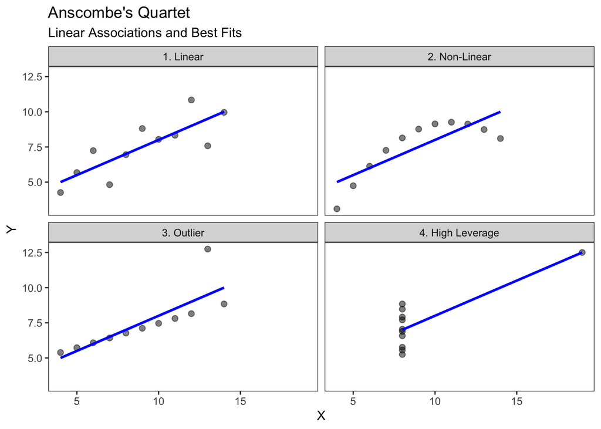

```r
library(tidyverse)
library(estimatr)
library(patchwork)

anscombe_tidy <- anscombe %>%
  pivot_longer(
    cols = everything(),
    names_to = c(".value", "set"),
    names_pattern = "(.)(.)"
  ) %>%
  mutate(set = case_when(set == 1 ~ "1. Linear", set == 2 ~ "2. Non-Linear", set == 3 ~ "3. Outlier", set == 4 ~ "4. High Leverage"))


ggplot(anscombe_tidy, aes(x = x, y = y)) +
  geom_point(size = 2, alpha = 0.5) +
  geom_smooth(method = "lm", se = FALSE, color = "blue") +
  labs(title = "Anscombe's Quartet",
       subtitle = "Linear Associations and Best Fits",
       x = "X",
       y = "Y") +
  theme_bw() +
  theme(panel.grid = element_blank())+
  facet_wrap(~set, ncol = 2)
```

Causation refers to the idea that some variable $X$ is responsible for changes in another variable $Y$. “$X$ is *doing something* to $Y$”. Alternatively, “$X$ causes $Y$ if, were we to intervene and *change* the value of $X$, then the distribution of $Y$ would *also* change as a result.” (Huntington-Klein 2022: 89)

Correlation may not imply causation because:

1. Causal relationships can exist even when there is no *observable correlation* between two variables (see Panel B).

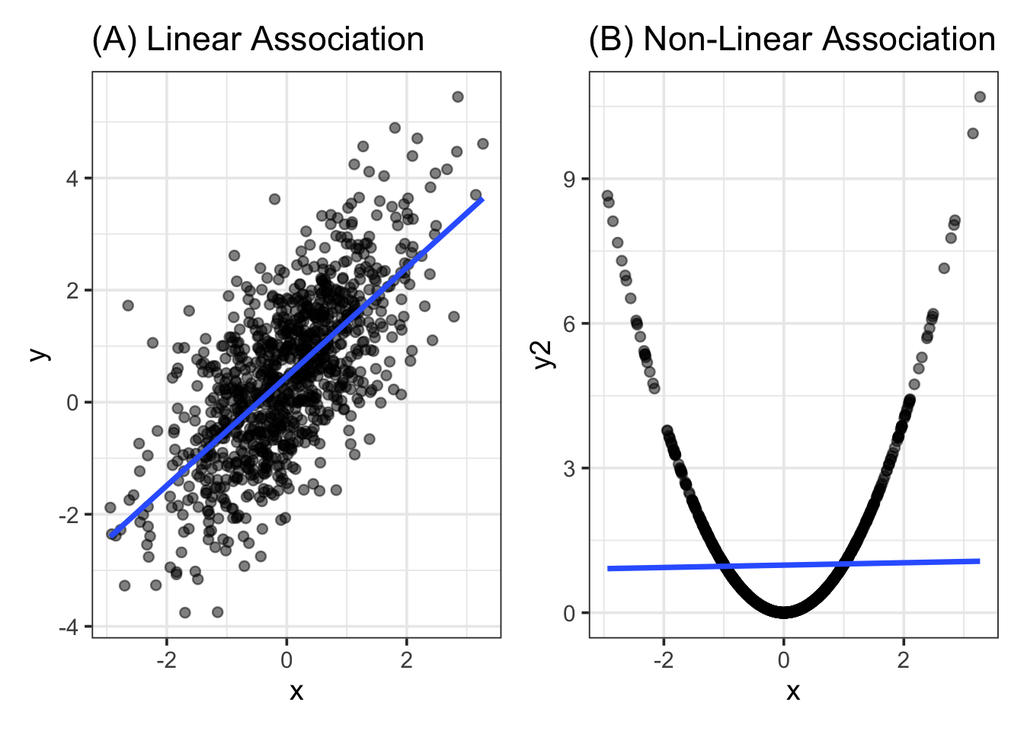

```r
set.seed(2025)

dat_correlation <- tibble(
  x = rnorm(1000, mean = 0, sd = 1),
  y = x + rnorm(1000, mean = 0.5, sd = 1),
  y2 = x ^ 2
)

fig1 = ggplot(data = dat_correlation, aes(x = x, y = y)) +
  geom_point(alpha = 0.5) +
  geom_smooth(method = "lm_robust", se = FALSE) +
  ggtitle("(A) Linear Association") +
  theme_bw(base_size = 14)

fig2 = ggplot(data = dat_correlation, aes(x = x, y = y2)) +
  geom_point(alpha = 0.5) +
  geom_smooth(method = "lm_robust", se = FALSE) +
  ggtitle("(B) Non-Linear Association") +
  theme_bw(base_size = 14)

fig1 + fig2
```

2. A causal relationship may not exist even when there is correlation (or association) between variables.

Example: Does attending a SAT preparation course cause an improvement in SAT scores? Attendance may be correlated with higher scores but *confounded* by other factors like motivation and affluence (more affluent or motivated students may be more likely to enroll in preparatory course *and* more likely to score higher on the test).

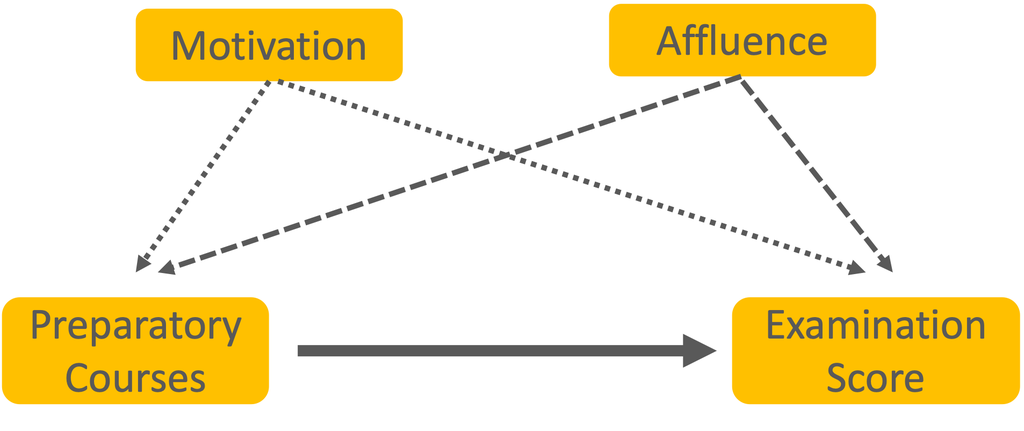

Figure 1: DAGs and Confounding

A directed acyclic graph (“DAG”) is a visual depiction of empirical associations. In the above example, attendance in preparatory classes ($X$) is associated with higher test scores ($Y$) but other confounding factors (motivation and affluence) affect $X$ and $Y$. There is an unblocked **backdoor path** connecting $X$ and $Y$, potentially confounding the association between these variables.

### Experiments and Confounding

Experiments randomly assign subjects to get an intervention (treatment group) or not (control group). The promise of this design is that “observed *and unobserved* factors that affect outcomes are equally likely to be present in the treatment and control groups” (FEDAI:8)

Put another way, “[t]he procedure of assigning treatments at random ensures that there is no systematic tendency for either the treatment or control group to have an advantage” (FEDAI:7)

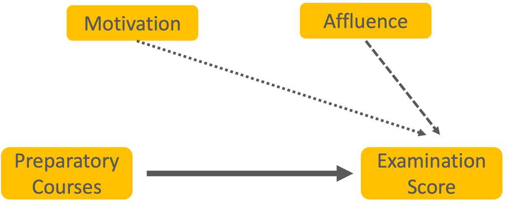

Figure 2: Experiments Deal With Confounding

# Types of Experiments

Experiments can be conducted in laboratory settings, embedded in surveys, or fielded in the real world.

A **natural experiment** is one in which someone other than the researcher (say a government) randomly assigns treatment.

A **quasi experiment** is when treatment is *as-if* randomly or plausibly randomly assigned. Note, someone (researcher or otherwise) did not actually randomly assign subjects to treatments. The process of assignment is “near-random”.

In an experiment, the researcher controls and determines the assignment of subjects to treatment(s).

A **field experiment** is an experiment that is: (i) conducted in a real world setting; (ii) involves participants that “resemble the actors who ordinarily encounter the intervention” (FEDAI:10); (iii) uses a treatment that “resembles the intervention of interest in the world” (FEDAI:10); and (iv) has outcomes that “resemble actual outcomes of theoretical or practical interest” (FEDAI:11).

**Note:** Random sampling is not the same as random assignment of treatment. Random sampling refers to the process by which subjects are selected into a study. It guarantees *representativeness*. Random assignment refers to how selected subjects are assigned to treatment(s). It deals with *confounding*. A randomly selected sample that is non-randomly assigned to treatment does *not* deal with confounding.

### Exercise

Identify the **best** research design to study each of the following research questions. You may use Claude or ChatGPT to brainstorm ideas.

1. What political views do “moderates” hold in America?
2. Does incumbency affect re-election prospects in future elections?
3. Does compulsory voting increase citizens’ political engagement?
4. Does exposure to globalization increase support for populist parties?
5. Why does ethnic diversity undermine the provision of public goods?